# Outbreak Response Scenario Modeling — Bootcamp

# Overview

This vignette walks through how to set up, run, and compare outbreak response (OBR) experiments using the `MRTransmissionModel` package. By the end you should be able to:

1. Read and interpret the `setup` object (country demography and vaccination history)
2. Understand every arguments in `EX.Country.part2.OR()`
3. Define a baseline scenario and one or more OBR scenarios
4. Compare scenarios and interpret the results
5. Decide how far into the future to project
6. Know when to use deterministic vs. stochastic mode

# 1. Load the package

```r
library(MRTransmissionModel)
source("R/setClasses.R")        # new OBR classes (not yet in installed package)
source("R/run.R")               # new OBR run method
source("R/EX.Country.part2.OR.R")  # new helper function
```

# 2. The setup object

`setupCountry.Nov2023()` pulls together all the country-specific inputs you need: demography, vaccination coverage history, and SIA timing. Everything downstream flows from this object.

```r
setup <- setupCountry.Nov2023(country = "Zambia")
names(setup)
```

```
##  [1] "uncode"                         "iso3code"
##  [3] "pop.total.1950.2100"            "pop.age.byageclasses.1950.2100"
##  [5] "tfr.1950.2100"                  "e0.1950.2100"
##  [7] "asfr.1950.2100"                 "repro.age.sex.dist.1950.2100"
##  [9] "births.1950.2100"               "cbr.1950.2100"
## [11] "yr.agespecificbirths.per.1000"  "asdr.1950.2100.by5"
## [13] "asdr.object"                    "get.births.here"
## [15] "MCV1.coverage.1980to2100"       "MCV2.coverage.1980to2100"
## [17] "RCV1.coverage.1980to2100"       "measlesSIA.coverage.1980to2100"
## [19] "age.max.sia.measles"            "age.min.sia.measles"
## [21] "rubellaSIA.coverage.1980to2100" "age.max.sia.rubella"
## [23] "age.min.sia.rubella"            "inaccessible.prop.1980.to.2100"
```

## 2.1 Demography

### Crude birth rate over time

`cbr.1950.2100` is the crude birth rate (births per 1000 population per year) for every year from 1950 to 2100. The model uses this to update the birth rate at each time step.

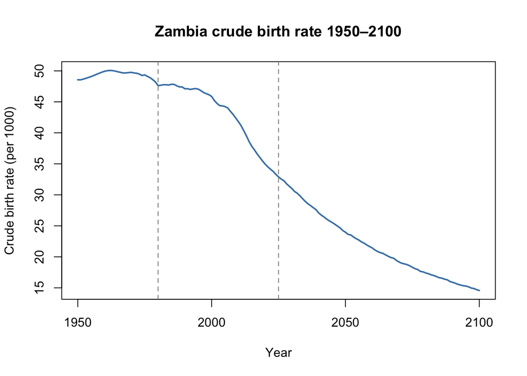

```r
years.demog <- 1950:2100
plot(years.demog, setup$cbr.1950.2100,
     type = "l", lwd = 2, col = "steelblue",
     xlab = "Year", ylab = "Crude birth rate (per 1000)",
     main = "Zambia crude birth rate 1950–2100")
abline(v = c(1980, 2025), lty = 2, col = "gray50")
```

### Total population over time

`pop.total.1950.2100` is the total population for each year. This is used to rescale the simulated population at specified time points so it does not drift from known values.

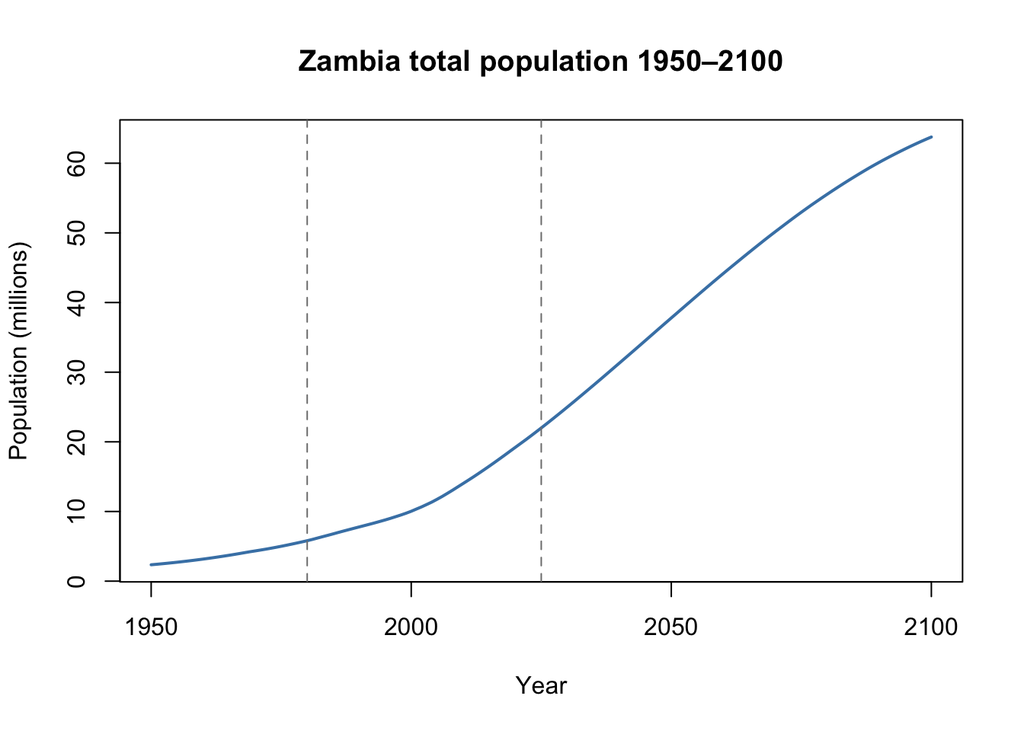

```r
plot(years.demog, setup$pop.total.1950.2100 / 1e6,
     type = "l", lwd = 2, col = "steelblue",
     xlab = "Year", ylab = "Population (millions)",
     main = "Zambia total population 1950–2100")
abline(v = c(1980, 2025), lty = 2, col = "gray50")
```

## 2.2 Vaccination coverage

Coverage vectors all run from 1980 to 2100. Years beyond the last data year (2022) are filled forward using the mean of 2018, 2019, and 2022 (COVID-robust average).

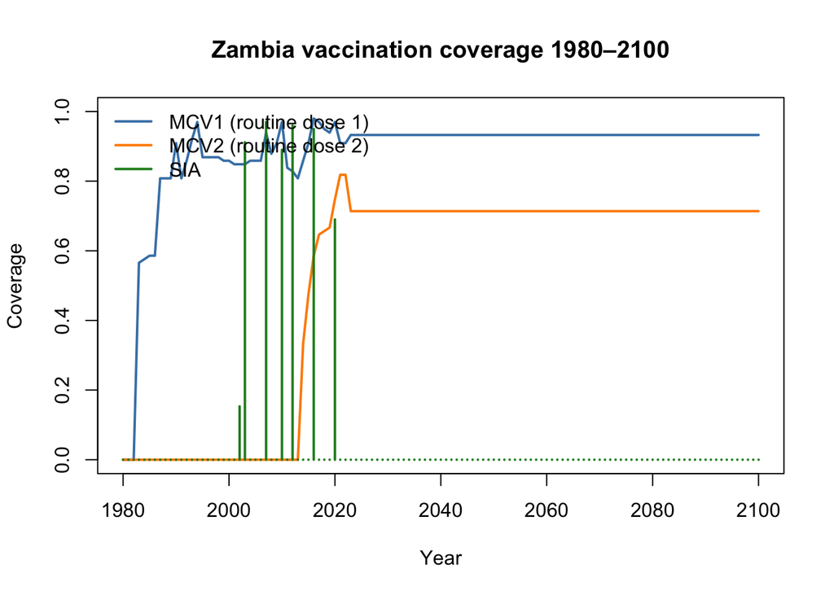

```r
years.vac <- 1980:2100

plot(years.vac, setup$MCV1.coverage.1980to2100,
     type = "l", lwd = 2, col = "steelblue",
     ylim = c(0, 1), xlab = "Year", ylab = "Coverage",
     main = "Zambia vaccination coverage 1980–2100")
lines(years.vac, setup$MCV2.coverage.1980to2100, lwd = 2, col = "darkorange")
lines(years.vac, setup$measlesSIA.coverage.1980to2100, lwd = 2, col = "forestgreen",
      type = "h")  # vertical lines — SIAs are single-year events
legend("topleft",
       legend = c("MCV1 (routine dose 1)", "MCV2 (routine dose 2)", "SIA"),
       col = c("steelblue", "darkorange", "forestgreen"),
       lwd = 2, bty = "n")
```

### SIA age targets

```r
sia.years <- years.vac[setup$measlesSIA.coverage.1980to2100 > 0]
sia.cov   <- setup$measlesSIA.coverage.1980to2100[setup$measlesSIA.coverage.1980to2100 > 0]
sia.amin  <- setup$age.min.sia.measles[setup$measlesSIA.coverage.1980to2100 > 0]
sia.amax  <- setup$age.max.sia.measles[setup$measlesSIA.coverage.1980to2100 > 0]

data.frame(year     = sia.years,
           coverage = round(sia.cov, 2),
           age.min  = sia.amin,
           age.max  = sia.amax)
```

```
##   year coverage age.min age.max
## 1 2002     0.15       6     180
## 2 2003     0.91       6     180
## 3 2007     0.97       9      59
## 4 2010     0.89       9      47
## 5 2012     0.96       9     168
## 6 2016     0.95       9     168
## 7 2020     0.69       9      59
```

## 2.3 Vaccine success by age

`pvacsuccess()` converts a vaccine efficacy curve into age-specific probabilities that a vaccine dose results in seroconversion. The Boulianne curve peaks around 12–15 months and falls off at younger ages due to maternal antibody interference.

This matters for OBR because campaigns targeting very young infants will have lower effective coverage than campaigns targeting older children, even if the nominal coverage is the same.

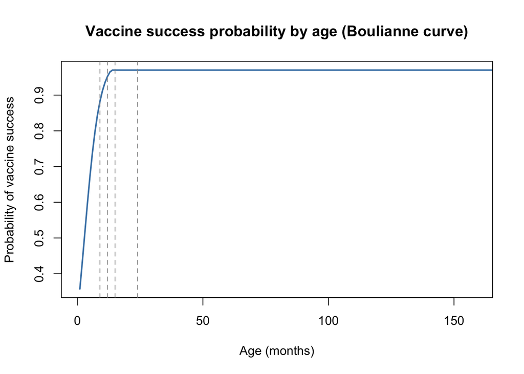

```r
age.classes <- c(1:240, seq(252, 1212, 12))  # months
vsucc.obj   <- pvacsuccess(age.classes, get.boulianne.vsucc())

plot(vsucc.obj@ages, vsucc.obj@prob.vsucc,
     type = "l", lwd = 2, col = "steelblue",
     xlim = c(0, 159),
     xlab = "Age (months)", ylab = "Probability of vaccine success",
     main = "Vaccine success probability by age (Boulianne curve)")
abline(v = c(9, 12, 15, 24), lty = 2, col = "gray60")
text(9, 0.1, "9m\n(MR1 min)", cex = 0.7, adj = 0)
text(15, 0.1, "15m\n(MR2 min)", cex = 0.7, adj = 0)
```

## 2.4 MCV1 age-at-vaccination distribution

`get.MR1cdf.survival()` builds the cumulative distribution of ages at which MCV1 is actually received, accounting for the fact that children do not all receive it on the day they turn 9 months. The distribution is parameterized from country-specific data.

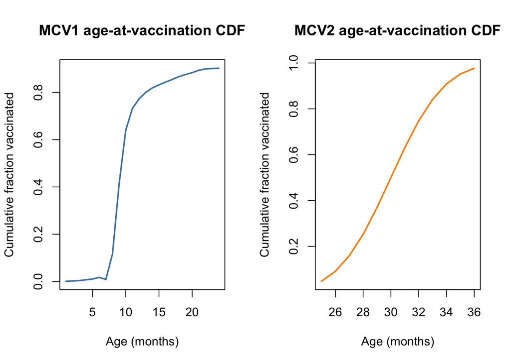

```r
vcdf.MR1 <- get.MR1cdf.survival(uncode = setup$uncode, 1, 24)
vcdf.MR2 <- get.vcdf.normal(25, 36)

par(mfrow = c(1, 2))
plot(vcdf.MR1@ages, vcdf.MR1@cdf,
     type = "l", lwd = 2, col = "steelblue",
     xlab = "Age (months)", ylab = "Cumulative fraction vaccinated",
     main = "MCV1 age-at-vaccination CDF")
plot(vcdf.MR2@ages, vcdf.MR2@cdf,
     type = "l", lwd = 2, col = "darkorange",
     xlab = "Age (months)", ylab = "Cumulative fraction vaccinated",
     main = "MCV2 age-at-vaccination CDF")
```

```r
par(mfrow = c(1, 1))
```

# 3. Step 1 — `EX.Country.part1()`: running out the transients

`EX.Country.part1()` spins the model up from a disease-free equilibrium for 20 years so the age structure, maternal immunity, and infection dynamics stabilize before the vaccination scenario begins. The result (`EXt0`) is the shared starting point for all scenarios — run it once and reuse it.

```r
year  <- 1980

EXt0 <- EX.Country.part1(
  uncode                         = setup$uncode,
  generation.time                = 0.5,
  age.classes                    = c(1:60, seq(72, 1212, 12)), #c(1:240, seq(252, 1212, 12)),
  maternal.decay.rt              = 0.45,
  exponent                       = 0.97,
  frequency.dep                  = TRUE,
  yr.births.per.1000.acrossyears = rep(setup$cbr.1950.2100[year - 1950 + 1], 20),
  intro.rate                     = 1 / 24 / 320,
  tot.pop                        = NULL,
  targeted.intro                 = FALSE,
  R0                             = 14,
  t.max                          = 20,
  get.births                     = setup$get.births.here,
  seasonal.amp                   = 0.15,
  flat.WAIFW                     = FALSE,
  country.specific.WAIFW         = TRUE,
  vynnycky.waifw                 = FALSE,
  vynnycky.waifw.betas           = c(2, 1),
  asdr.object                    = setup$asdr.object,
  year                           = year,
  use_montagu_demog              = FALSE
)
```